# Hypothesis Testing - Homework 5

Consider the in-built R dataset “sleep”. This dataset compares the effects of two sleep medications. That is, the increase in number of hours of sleep in patients in comparison to a control.

```r
sleep
```

| extra | group | ID |
| --- | --- | --- |
| 0.7 | 1 | 1 |
| -1.6 | 1 | 2 |
| -0.2 | 1 | 3 |
| -1.2 | 1 | 4 |
| -0.1 | 1 | 5 |
| 3.4 | 1 | 6 |
| 3.7 | 1 | 7 |
| 0.8 | 1 | 8 |
| 0.0 | 1 | 9 |
| 2.0 | 1 | 10 |

[output cut: 10 more lines]

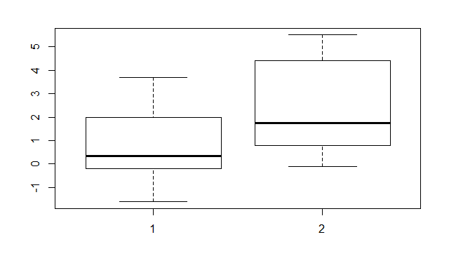

```r
extra <- sleep[,1]
group <- c(1,1,1,1,1,1,1,1,1,1,2,2,2,2,2,2,2,2,2,2)
boxplot(extra ~ group)
```

We immediately see the group one drug produces, on average, less of an increase in hours of sleep for each patient. This gives us a feel for whether we expect there to be a statistical difference. In order to test whether there is a difference between the two drugs effects we wish to test $H_0: \mu_1 - \mu_2 = 0$ against $H_1: \mu_1 - \mu_2 \ne 0$ where $\mu_1$ and $\mu_2$ are the mean extra hours slept for group one and group two respectively.

We first check whether the data are normally distributed. We check this by performing a qqplot of the patients in each group and checking the data is roughly normally distributed.

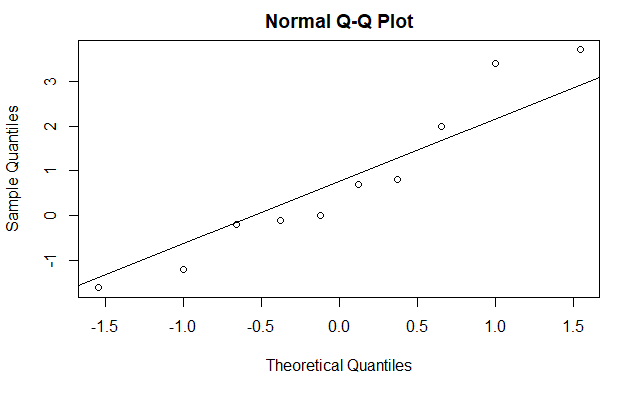

```r
extra1 <- extra[1:10]
extra2 <- extra[11:20]
qqnorm(extra1)
qqline(extra1)
```

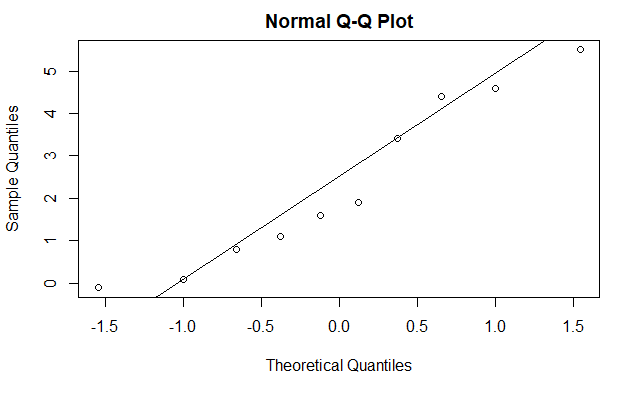

```r
qqnorm(extra2)
qqline(extra2)
```

Hence we see they are suitably normally distributed and so we wish to introduce a model using pairs of random variables $(X_i, Y_i)$. Let $D_i = X_i-Y_i$ for all $i$ then $D \sim N(\mu, \sigma^2)$ with unknown parameters $\mu$ and $\sigma^2$. We therefore use the t-test, test statistic. That is,

$$\frac{\sqrt{n} ( \bar{D}-\mu_0)}{S_D} \sim t(n-1)$$

under the null hypothesis $H_0: \mu = \mu_0$ where $S_D^2$ is the sample variance of the differences.

```r
n <- 10 #there are ten patients
difference <- extra1 - extra2
SD <- sqrt(var(difference))
tstat <- (sqrt(n)*(mean(difference) - 0))/SD
tstat
```

```
[1] -4.062128
```

```r
critval <- qt(0.95, 9)
critval
```

```
[1] 1.833113
```

We compare our calcualtions to R’s built-in t.test function

```r
t.test(difference, alternative="two.sided")
```

```
    One Sample t-test

data:  difference
t = -4.0621, df = 9, p-value = 0.002833
alternative hypothesis: true mean is not equal to 0
95 percent confidence interval:
 -2.4598858 -0.7001142
sample estimates:
mean of x
    -1.58
```